# 3.0 TSpectrum, vector, map

## TSpectrum

- This class contains advanced spectra processing functions for:
  - One-dimensional background estimation
  - One-dimensional smoothing
  - One-dimensional deconvolution
  - One-dimensional peak search

```python
TFile *f = new TFile("gamma.root")
```

```
(TFile *) 0x7f7d0e98ecd0
```

```python
f->ls()
```

```
TFile**		gamma.root
 TFile*		gamma.root
  KEY: TH1F	h0;1	152Eu gamma calibration
```

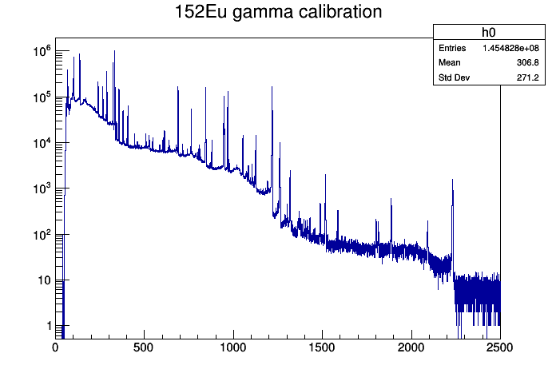

```python
TCanvas *c1 = new TCanvas;
h0->Draw();
c1->SetLogy();
c1->Draw();
```

### 创建TSpectrum对象

```python
TSpectrum *s = new TSpectrum(500);//maximum number of peaks
```

### 生成本底谱

```
TH1 * TSpectrum::Background( const TH1 *h,
                             Int_t niter = 20,
                             Option_t  *option = ""
                            )
```

- Parameters:
  - h: input 1-d histogram
  - niter: numberIterations, (default value = 20) Increasing numberIterations make the result smoother and lower.
    - 通过观察本底谱的形状，选择合适的niter参数。减本底的重要原则是宁少勿多，避免减出负值！

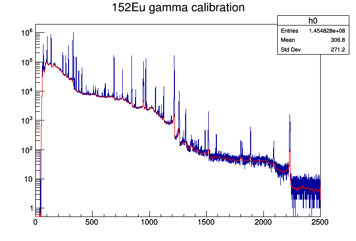

```python
TH1F *hb0 = (TH1F*)s->Background(h0, 15, "same");//本底侵入到峰区域！
h0->Draw();
hb0->SetLineColor(kRed);
hb0->Draw("same");
c1->Draw();
```

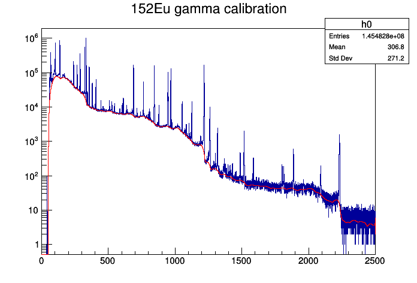

```python
TH1F *hb1 = (TH1F*)s->Background(h0, 30, "same");//给出了峰下连续谱的合理形状，本底参数合理。
h0->Draw();
hb1->SetLineColor(kRed);
hb1->Draw("same");
c1->Draw();
```

### 减本底

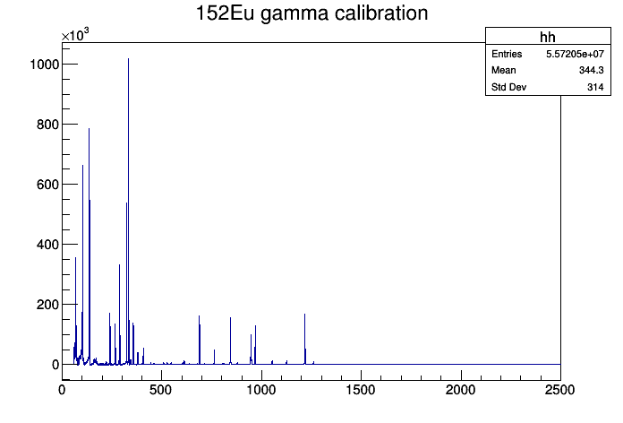

```python
h0->Clone("hh");
hh->Add(hh, hb1, 1, -1);//hh = 1 * hh-1 * hb
hh->Draw();
c1->SetLogy(0);
c1->Draw();
```

### 寻峰

```
Int_t TSpectrum::Search(const TH1  *hin,
                          Double_t sigma = 2,
                          Option_t *option = "",
                          Double_t threshold = 0.05
                        )
```

- Parameters:
  - hin: pointer to the histogram of source spectrum
  - sigma: sigma of searched peaks
  - threshold: (default=0.05) peaks with amplitude less than threshold * highest_peak are discarded. 0<threshold<1
- By default, the background is removed before deconvolution. Specify the option "nobackground" to not remove the background.
  - 建议通过Background功能选择合适的本底形状，减完本底后再寻峰！
- 得到寻峰值

```
Double_t *xpeaks, *ypeaks;
Int_t nfound = s->Search(hh,2,"",0.002);
xpeaks = s->GetPositionX();
ypeaks = s->GetPositionY();
```

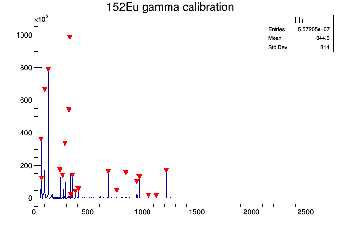

```
21
0: 332, 984052
1: 135, 786091
2: 101, 664539
3: 322, 538447
4: 67, 355974
5: 288, 331300
6: 239, 171454
7: 688, 161288
8: 1217, 167250
9: 843, 152510
10: 356, 139327
11: 265, 136479
12: 968, 127081
13: 71, 117777
14: 946, 100460
15: 406, 53913
16: 762, 46709.3
17: 379, 38620.6
18: 342, 16484.9
19: 1125, 13541.8
20: 1053, 12435.7
```

```python
Double_t *xpeaks, *ypeaks;
Int_t nfound = s->Search(hh,2,"",0.005);
cout<<nfound<<endl;
xpeaks = s->GetPositionX();
ypeaks = s->GetPositionY();
for(int i=0; i<nfound; i++)
    cout << i << ": " << int(xpeaks[i])
         << ", " << ypeaks[i] << endl;
hh->Draw();
c1->Draw();
```

### 改变阈值

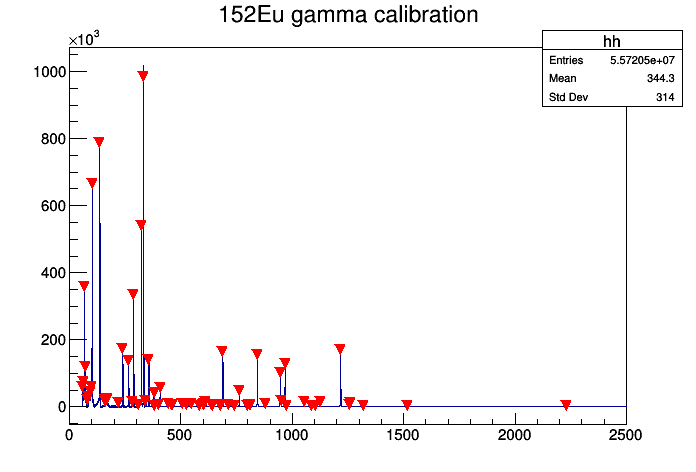

```
65
```

```python
nfound = s->Search(hh, 2, "", 0.001);
cout << nfound << endl;
hh->Draw();
c1->Draw();
```

## std::vector (c++ STL )

- include

```
#include <vector>
#include <algorithm>
```

### 声明

```
vector<int> v;
```

### 尾部插入元素

```
for(int i=0; i<10; i ++) {
    v.push_back(i);
}
```

### 遍历vector中的元素：

```
for (int i=0; i<v.size(); i++) {
     cout << v[i] << " ";
}
```

- 通过迭代器遍历: 参见map部分：正向遍历、反向遍历

### 查找元素

- 通过迭代器进行访问

```
vector<int> vec = {1, 2, 3, 4, 5};
vector<int>::iterator it = vec.find(3); //可以用 auto it = vec.find(3)；代替

if (it != vec.end()) {
    cout << "Found " << *it << endl;
}
else {
    cout << "Element not found" << endl;
}
```

#### 其他常用函数

- pop_back(): 删除向量的最后一个元素。
- erase(): 删除指定位置的元素。
- clear(): 删除向量中的所有元素。

## std::map (c++ STL )

- include

```
#include <map>
#include <algorithm>
```

- map是STL（标准模板库）的一个关联容器。
- map提供一对一的数据处理，key-value键值对，其类型可以自己定义，第一个称为关键字，第二个为关键字的值

[figure not shown]

- multimap可以允许多个key值是相同的，而map的key值不允许重复。
- map, multimap, 按照key值的大小自动排序，key值由小到大。

### 定义map变量

```python
map<Int_t, Double_t> m1;//第一个是键的类型，第二个是值的类型
multimap<Int_t, Double_t> mul1;
```

### 赋值

```python
for(int i=0; i<nfound; i++){
    int key = xpeaks[i];
    double value = ypeaks[i];
    m1.insert(make_pair(key, value));//插入key，value值
    m1.insert(make_pair(key, value));//插入key，value值
    mul1.insert(make_pair(key, value));
    mul1.insert(make_pair(key, value));//重复插入key，value值
}
```

### 查看大小

```python
cout << m1.size() << "," << mul1.size();
```

```
65,130
```

### 查找元素

- 通过迭代器进行访问

`map<Int_t,Double_t>::iterator im1;`

- im1->first来访问key，使用im->second访问value
- maps.find() 查找一个元素
- find(key): 返回键是key的映射的迭代器

```python
int i = 762;
auto im1 = m1.find(i);//map<Int_t,Double_t>::iterator im1=m1.find()
if(im1 != m1.end())
    cout << im1->first << ", " << im1->second << endl;
else
    cout << "key=" << i << " is not found." << endl;
i = 100;
im1 = m1.find(i);
if(im1 != m1.end())
    cout << im1->first << ", " << im1->second << endl;
else
    cout << "key=" << i << " is not found." << endl;
```

```
762, 46709.3
key=100 is not found.
```

### 正向遍历

- m1.begin()返回指向map头部的迭代器
- m1.end()返回指向map末尾的迭代器

```python
int num = 0;
cout<<"map elements:"<<endl;

for(auto im=m1.begin(); im!= m1.end(); im++) {
    if(num > 10) break;
    cout << "  " << im->first << ", " << im->second << endl;
    num++;
}
num = 0;
cout << "multimap elements:" << endl;
for(auto imul=mul1.begin(); imul!=mul1.end(); imul++){
    if(num > 10) break;
    cout << "  " << imul->first << ", " << imul->second << endl;
    num++;
}
```

```
map elements:
  59, 57259.4
  63, 71649.2
  67, 355974
  71, 117777
  78, 18438.1
  86, 28650.3
  94, 43538.8
  96, 57888.3
  101, 664539
  135, 786091
  160, 17473.4
multimap elements:
  59, 57259.4
  59, 57259.4
  63, 71649.2
  63, 71649.2
  67, 355974
  67, 355974
  71, 117777
  71, 117777
  78, 18438.1
  78, 18438.1
  86, 28650.3
```

### 反向遍历

- m1.rbegin()返回指向map尾部的逆向迭代器
- m1.rend()返回指向map头部的逆向迭代器

```python
num = 0;
cout << "map elements:" << endl;
for(auto im=m1.rbegin(); im!=m1.rend(); im++) {
    if(num > 10) break;
    cout << "  " << im->first << ", " << im->second << endl;
    num++;
}
num = 0;
cout << "multimap elements:" <<endl;
for(auto imul=mul1.rbegin(); imul!=mul1.rend(); imul++){
    if(num > 10) break;
    cout << "  " << imul->first << ", " << imul->second << endl;
    num++;
}
```

```
map elements:
  2231, 1541.63
  1516, 1940.93
  1318, 2344.95
  1261, 9518.89
  1258, 4217.79
  1217, 167250
  1125, 13541.8
  1104, 2206.72
  1084, 1579.06
  1053, 12435.7
  975, 1833.7
multimap elements:
  2231, 1541.63
  2231, 1541.63
  1516, 1940.93
  1516, 1940.93
  1318, 2344.95
  1318, 2344.95
  1261, 9518.89
  1261, 9518.89
  1258, 4217.79
  1258, 4217.79
  1217, 167250
```

#### 其他成员函数

- maps.clear(): 清空
- maps.erase(): 删除一个元素
- maps.lower_bound(): 会返回一个迭代器，它指向键值和参数相等或大于参数的第一个元素。
- maps.upper_bound(): 返回一个迭代器，它指向键值大于函数参数的第一个元素。

更多用法见第5章